# Basics of Linear Modeling

[EFB 390](https://eligurarie.github.io/EFB390/) - Fall 2024

Dr. Elie Gurarie

2026-09-29

> **Goals**
> 1. Load data
> 2. Understand **continuous** and **discrete** data
> 3. **summary statistics** and **visualizations**
> 4. Fit and analyze a simple **linear model**

> There are **4 Exercises** in the lab that need to be submitted on Blackboard.

# 1 Loading and working with data frames

> The following examples should explain how to import data frames and to work with the data contained within them.

## 1.1 Loading Data

We will use Steller sea lion (*Eumotopias jubatus*) data as an example. These are weights, lengths, and girths (basically, under the arm/flipper pits) of sea lion pups about two months after birth as part of a tagging mark-recapture study. These data were collected (in part by Dr. Gurarie) on five islands in the North Pacific.

This is what sea lion pups look like:

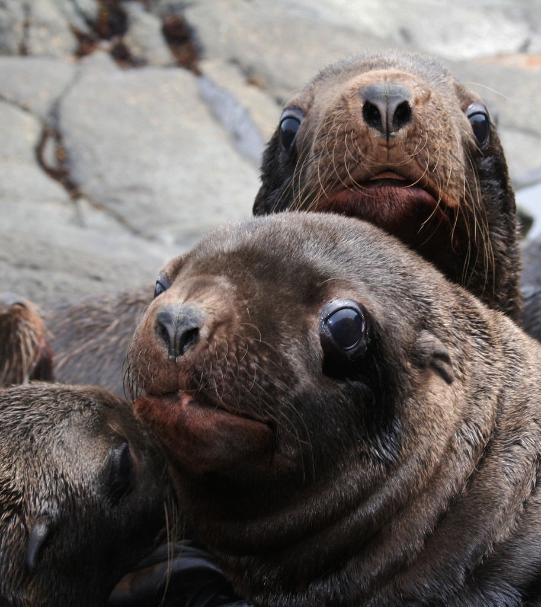

This dataset is available on Blackboard as `SeaLions.csv`, or at this link. Once you download it, you can use the File Explorer to determine its location and read it into R in a couple of ways:

1. **From the command line:** you can download the dataset and modify the following line of code:

```r
SeaLions <- read.csv("insert the directory instead of this sentence/SeaLions.csv")
```

A directory is another way to refer to a folder or, simply, a location of a data file on your computer. You can get the address of the directory if you open the folder where you saved the file through File Explorer, right-click on the navigation bar and select `Copy address as text` option. Note: If you copy and paste the file directory in, you **have to change the direction of the slashes** from `\` to `/`!

Note that `csv` is a **text based** file type (Comma Separated Values) - it just means that commas between entries indicate separate columns. When a program “reads” the file, it “knows” that a comma means the end of one column and the start of another one. You can save any Excel file as a `csv` using the **Save As** function. CSVs are by far the the most common and convenient file type used for loading into R.

2. Alternatively, you can import datasets into `R` using the `RStudio` point-and-click interface. To do this:
- 1. Navigate to the `Files` tab in the bottom right corner of RStudio
- 2. Click on `SeaLions.csv`
- 3. RStudio will prompt you to either view the file or import the dataset. You want to import, so hit `Import File`
- 4. A pop-up window will appear, showing you the preview of the data frame. Click `Import` and observe that your file is now loaded - it should have appeared in your Environment in the top right corner of RStudio.

This method does the same exact thing as the line of code above. It will automatically input the proper code into the console and save your file to the environment. Note that by default the file will have the same name rather than a name you designate for it.

## 1.2 Working with data frames

Look at some properties of this data file, with the following functions:

```r
is(SeaLions) # tells what type of files we have
```

```
## [1] "data.frame" "list"       "oldClass"   "vector"
```

```r
names(SeaLions) # tells us the names of all the columns
```

```
## [1] "Island" "Weight" "Length" "Girth"  "Sex"
```

```r
head(SeaLions) # shows the first several rows of the dataframe
```

|  | Island | Weight | Length | Girth | Sex |
| --- | --- | --- | --- | --- | --- |
| 1 | Chirpoev | 15.5 | 93 | 69.0 | M |
| 2 | Chirpoev | 29.0 | 106 | 71.0 | F |
| 3 | Chirpoev | 35.5 | 112 | 76.0 | M |
| 4 | Chirpoev | 32.0 | 107 | 72.0 | M |
| 5 | Chirpoev | 32.0 | 105 | 73.5 | M |
| 6 | Chirpoev | 33.5 | 111 | 72.0 | M |

Use a `$` to extract a given column:

```r
Length <- SeaLions$Length
Weight <-SeaLions$Weight
Island <- SeaLions$Island
Sex <- SeaLions$Sex
```

# 2 Summary Statistics

Just about all data can be broken into **categorical data** or **continuous data**. Continuous data is numeric, and you can calculate a bunch of familiar statistics (means, ranges, medians, etc.)

```r
range(Length) # range
```

```
## [1]  93 126
```

```r
median(Length) # median
```

```
## [1] 110
```

```r
mean(Length) # mean
```

```
## [1] 109.8434
```

```r
var(Length) # variance
```

```
## [1] 34.82854
```

```r
sd(Length) # standard deviation
```

```
## [1] 5.901571
```

Categorical data comes in discrete, countable sets of options, called **factors** or **levels**. The best statistic for categorical data is just to count them. That’s done with the super useful `table()` function:

```r
table(Sex)
```

```
## Sex
##   F   M
## 226 272
```

```r
table(Island)
```

```
## Island
## Antsiferov   Chirpoev   Lovushki    Raykoke   Srednova
##        100         99        100        100         99
```

```r
table(Island, Sex)
```

```
##             Sex
## Island        F  M
##   Antsiferov 38 62
##   Chirpoev   43 56
##   Lovushki   50 50
##   Raykoke    49 51
##   Srednova   46 53
```

# 3 Graphical Summaries

**Categorical** and **Continuous** data are illustrated and analyzed in different ways.

## 3.1 Continuous data

**Continuous data** contains a lot of different values. The best way to see the spread (*distribution*) of those data is with a histogram - the `hist()` functino:

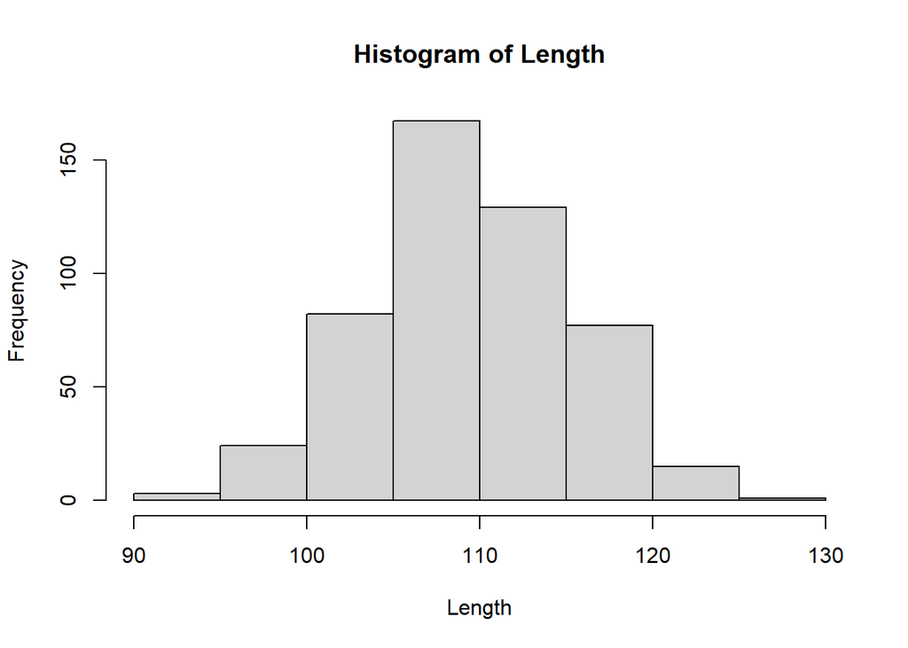

```r
hist(Length)
```

> **Exercise 1:** Produce a histogram of the **Weight** of the sea lion pups. Also, report the **minimum**, **maximum** and **mean** weight of the sea lion puops. Copy and paste that figure into a Word or Google document

## 3.2 Categorical data

For categorical data, you want to represent the counts. The best choices are bar charts:

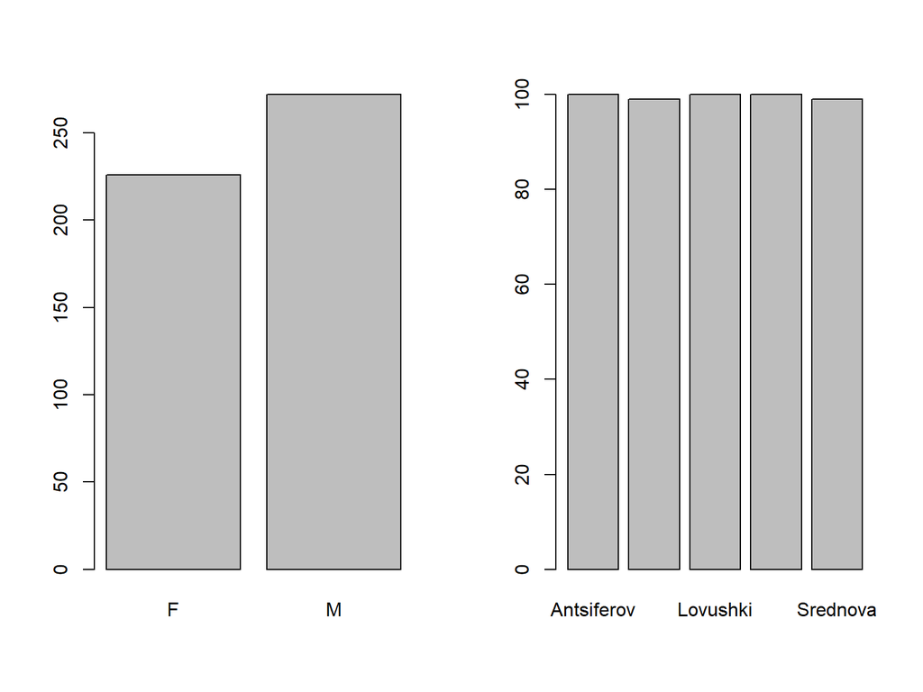

```r
barplot(table(Sex))
barplot(table(Island))
```

Or pie charts (which are very rarely used in scientific analyses).

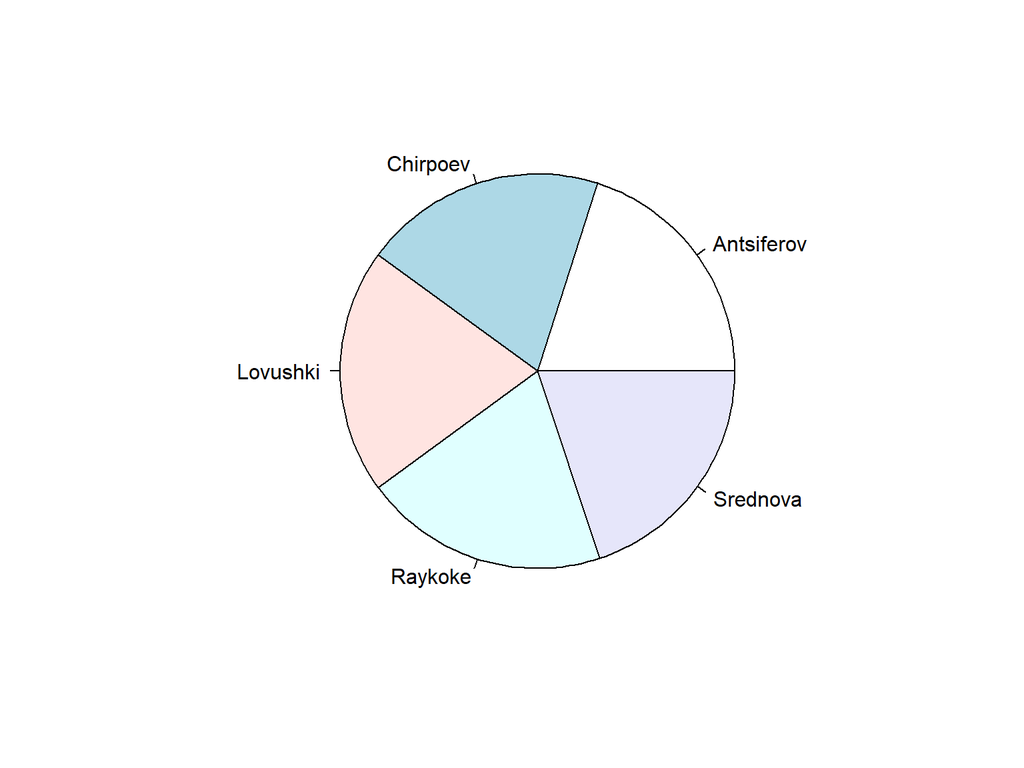

```r
pie(table(Island))
```

> **Exercise 2:** Just run the following code to make a barplot of *both* sex and island. Copy paste the figure into a Word / Google document.

```r
barplot(table(Sex, Island))
```

## 3.3 Boxplot

A boxplot shows us relationships between a continuous variable (like Length/Weight/Girth) and a discrete variable (like Island/Sex). The box contains the *median*, and 25% and 75% *quantiles* and shows points that are outside of an “extreme” range of 1.5 x the resepective interquantile range:

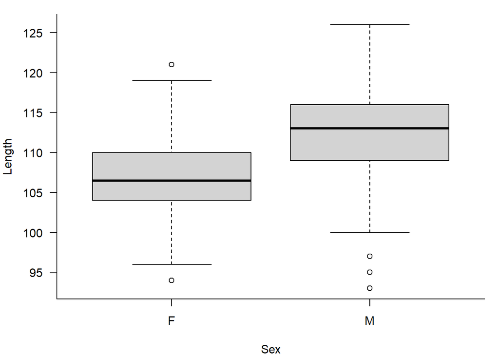

```r
boxplot(Length ~ Sex, data = SeaLions)
```

Which sex do you think is generally longer!?

> **Exercise 3:** Produce a boxplot of the **Weight** of the sea lions against Islands. Do you think there is a significant difference against Islands?

## 3.4 Scatterplot

Finally, a scatterplot shows us relationships between two continuous variables. It is the easiest plot:

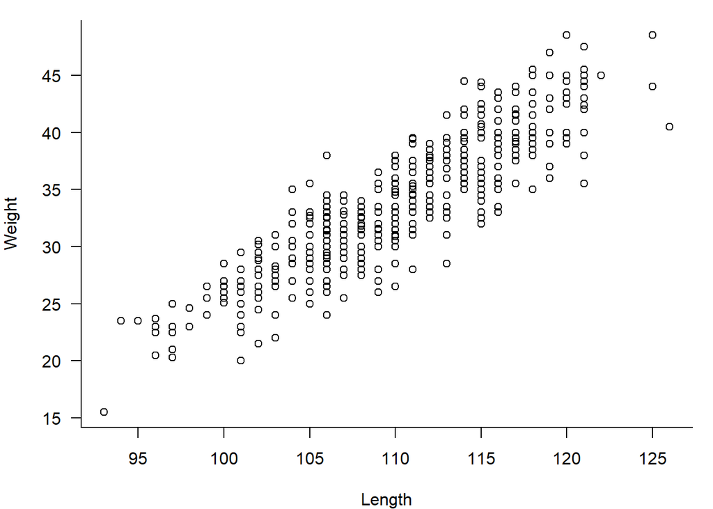

```r
plot(Length, Weight)
```

Very briefly, with no additional details, the following bit of code will fit a **regression line** on these data using the `lm()` (linear model) command:

```r
lm(Weight ~ Length, data = SeaLions)
```

```
##
## Call:
## lm(formula = Weight ~ Length, data = SeaLions)
##
## Coefficients:
## (Intercept)       Length
##    -59.5108       0.8468
```

*Think about what those numbers mean*.

And the next two sets of lines will PLOT the data AND plot the linear regression, using the `abline()` command which plots intercept - slope lines:

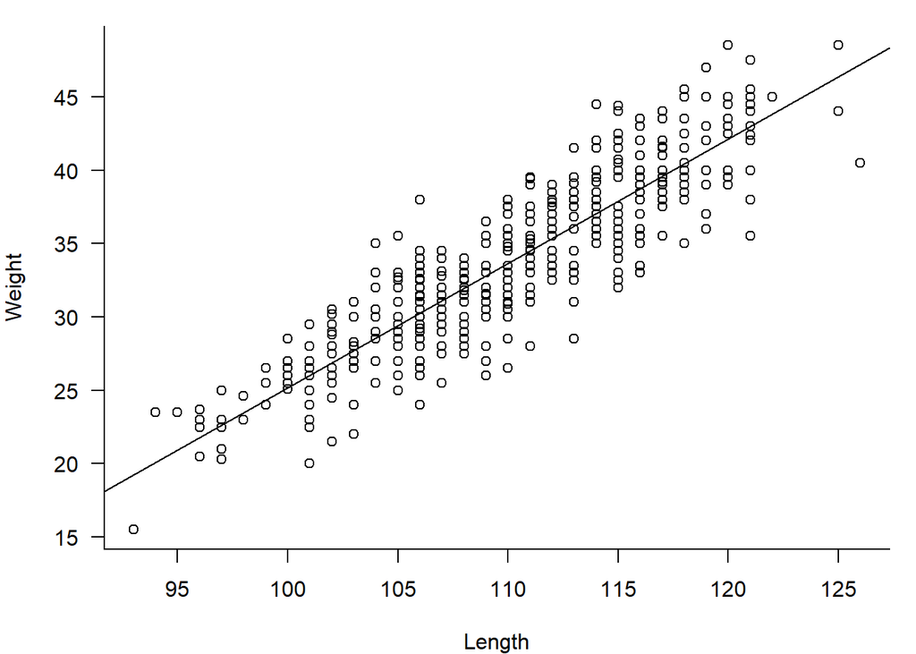

```r
plot(Weight ~ Length, data = SeaLions)
abline(lm(Weight ~ Length, data = SeaLions))
```

# 4 Analyzing sex differences

Here’s an important question: Do **male** and **female** show the same length-weight relationship? We know that adult Steller sea lions are extremely **sexually dimorphic** (adult males are ~1000 kg, adult females closet to ~400 kg). Is that dimorphism expressed at an early stage as well?

## 4.1 Subsetting data

You can subset all your data using the `subset()` command, like this:

```r
SeaLions_M <- subset(SeaLions, Sex == "M")
SeaLions_F <- subset(SeaLions, Sex == "F")
```

Note the **logical comparisons** (equal to: `==` or greater than `>`). The double equal sign “X == Y” means: *is X equal to Y*, and will give a TRUE | FALSE response.

Now you can extract whatever variables you want using these two new datasets:

```r
mean(SeaLions_M$Length)
```

```
## [1] 112.4632
```

```r
mean(SeaLions_F$Length)
```

```
## [1] 106.6903
```

> **Exercise 4:** Answer the question *Is the length-weight relationship of male and female pups different?* by following these steps:
> 1. Subset the data to males and females
> 2. Obtain *mean*, *standard deviation* and *range* of **weight** and **length** for males and females.
> 3. Plot the weight and length relationship for males and females.
> 4. Obtain the linear model coefficients for both males and females.
> 5. Plot the regression lines on top of those plots
> 6. Answer: Do males of females put on more weight as they grow?

[figure not shown]

Sleepy family (my picture!)